This was just a fun morning exercise. Let’s mix multiple images to make a palette of their principal colors using k-means.

This just copies http://www.milanor.net/blog/build-color-palette-from-image-with-paletter/ with the added twist of using multiple images before creating the palette. I wanted to see if some cartoon show palettes using this method matched those in the ggsci package. The ggsci palettes don’t seem particularly attractive. Did the authors use the algorithmic approach I will use here? Will my approach look any better? Don’t know. I decided to use “Rick and Morty” because my kids like it. I would certainly never watch such drivel. I’m a scientist.

For the record, the one pop culture derived palette I really like is the Wes Anderson palette available here: https://github.com/karthik/wesanderson and on CRAN. These are presumably lovingly curated and created, not like the ones created by the stupid robots I use here.

load libraries

```
library(tidyverse)




library(jpeg)
library(scales)

##

library(ggsci)
```

Load mulitple images. They are all Google image search thumbnails so the size is the same. This matters since we are combining images a larger image would have a disproportional weight in our analysis.

I first thought that, since I am combining multiple images to get one palette, I needed to tile the images then process. No. We just care about the pixel color values so it really doesn’t matter what position they are in. The most efficient approach is to just chain all the RGB values together. Duh. Still we want to do some work with the individual images so let’s label them.

```
rm_list<-list()
for (n in 1:6){
  print(paste0("img/rm",n,".jpg"))
  img<-jpeg::readJPEG(paste0("img/rm",n,".jpg"))
  R<-as.vector(img[,,1])
  G<-as.vector(img[,,2])
  B<-as.vector(img[,,3])
  rm_list<-bind_rows(data_frame(img=n,R,G,B),rm_list) %>%
    arrange(img)
}

## [1] "img/rm1.jpg"


## [1] "img/rm2.jpg"
## [1] "img/rm3.jpg"
## [1] "img/rm4.jpg"
## [1] "img/rm5.jpg"
## [1] "img/rm6.jpg"

rm_list <- left_join(rm_list,
                     data_frame(
                     img = c(1, 2, 3, 4, 5, 6),
                     name = c("Schwifty","Portal","Cable",
                     "Family", "Outdoor", "Wedding")
                     ))
```

# Show Me What You Got

For fun let’s do some density plots of the color values.

```
#make data tidy first
rm_tidy <- rm_list %>% gather("color","level",-img,-name)
ggplot(rm_tidy,aes(x=level,fill=color))+
  geom_density(alpha=0.7) +
  scale_fill_manual(values=c("blue","green","red")) +
  theme_void()
```

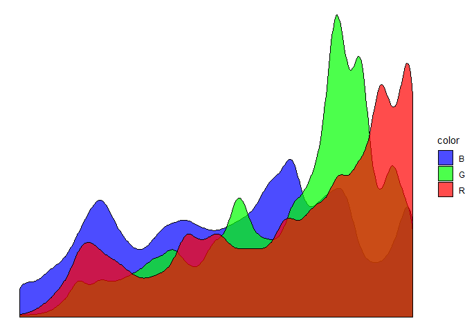

We can see some evidence of bimodality, a preference for very bright and very dark hues. Red is more often cranked to the max, while blue is much more evenly distributed. Perhaps that is typical of the limited palette of cartoons or just a function of the small number of frames I chose.

I chose the images to be representative of varying but typical scenes. Let’s look at the histograms for each.

[figure not shown]

Cable

[figure not shown]

Family

[figure not shown]

Wedding

[figure not shown]

Outdoor

[figure not shown]

Portal

[figure not shown]

Schwifty

```
ggplot(rm_tidy,aes(x=level,fill=color))+
  geom_density(alpha=0.7) +
  scale_fill_manual(values=c("blue","green","red")) +
  facet_wrap(~name)+
  theme_void()
```

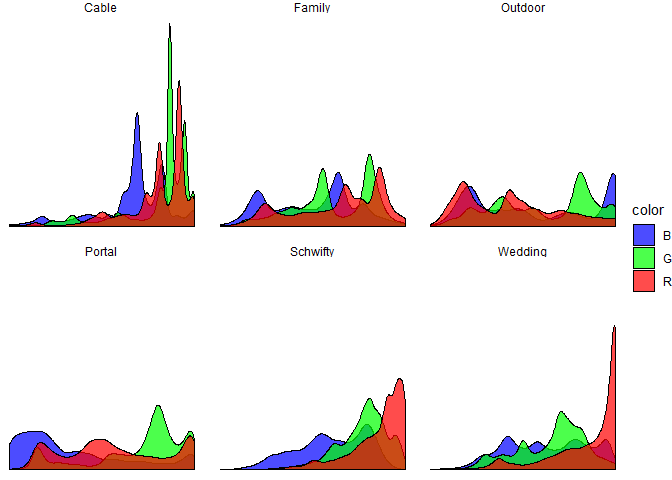

It’s interesting to compare “Cable” with “Family.” Both images share the same backdrop but “Family” is much darker.

# Make the palettes

When I was a kid with watercolors I wanted to come up with a name for the filthy color that resulted when I mixed all the colors together. I called it “Hitler” (but, really, brown). What is the color that results when we average all the RGB values? What named R colors resemble it?

```
blend_color<-rm_list %>%
  summarise(R=mean(R),G=mean(G),B=mean(B)) %>%
  rgb()

show_col(c("cornsilk4",blend_color,"darkkhaki"))
```

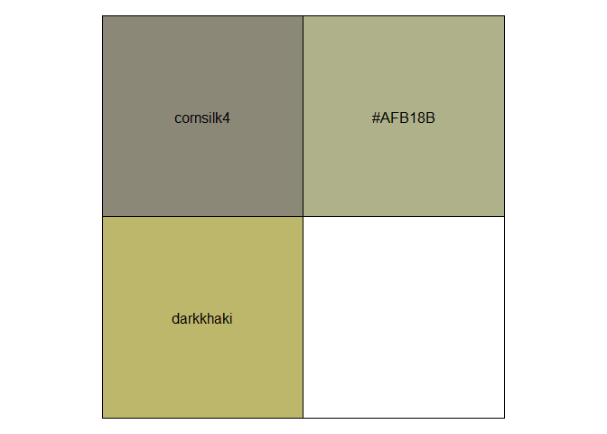

Let’s call it “desertkhaki” which, hopefully, is not a trigger word.

Now, for the fun part. In the Wes Anderson palette set, each movie get’s a different palette. Let’s make palettes for each of the images, which I chose for their distinctiveness.

For me, the good thing about open source is that I can stand on the shoulders of giants in the community. R also makes very muscular analysis trivally simple. On the other hand it makes “script kiddies” like me potentially dangerous. I can only describe k-means in the most general terms but can run it in a snap.

```
num_colors = 16
pal_schwifty <- rm_list %>%
  filter(name=="Schwifty") %>%
  select(R,G,B) %>%
  kmeans(centers = num_colors, iter.max = 30) %>%
  .$centers %>%
  rgb()

show_col(pal_schwifty)
```

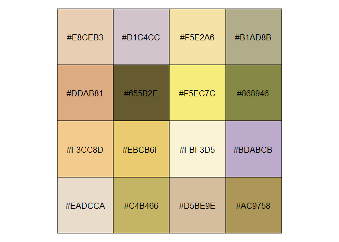

For data plotting the separation between some of these colors is too small. I think 9 colors will suffice.

```
num_colors = 9
pal_schwifty <- rm_list %>%
  filter(name=="Schwifty") %>%
  select(R,G,B) %>%
  kmeans(centers = num_colors, iter.max = 30) %>%
  .$centers %>%
  as.tibble() %>%
  {.}

show_col(rgb(pal_schwifty))
```

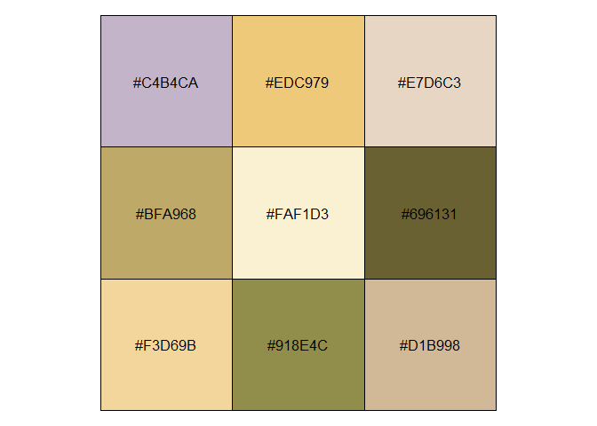

For plotting purposes I would like use these colors in order of intensity.

```
pal_schwifty %>%
  mutate(saturation=rowSums(.[1:3])) %>%
  arrange(saturation) %>%
  rgb() %>%
  show_col()
```

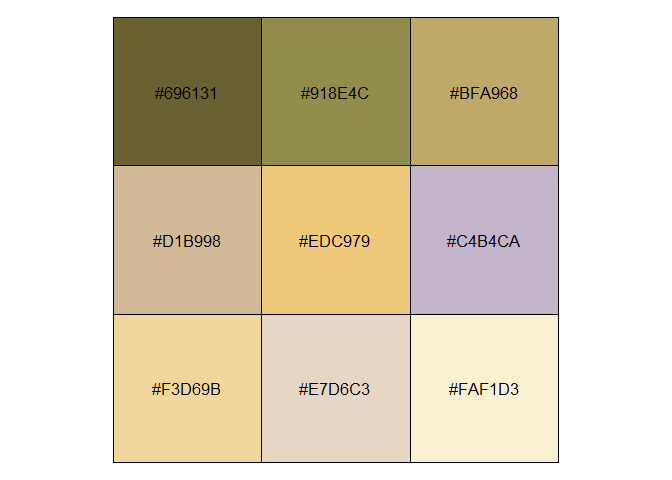

That’s about right. Now go through all the images to great a series of palettes.

```
#function to turn a table of RGB values to an ordered list of colors
gen_pal<- function(rgb_table){
num_colors = 9
pal <- rgb_table %>%
  select(R,G,B) %>%
  kmeans(centers = num_colors, iter.max = 30) %>%
  .$centers %>%
  as.tibble() %>%
  mutate(saturation=rowSums(.[1:3])) %>%
  arrange(saturation) %>%
  rgb() %>%
  {.}
return(pal)

}

#now make list columns, which are totally awesome, for each palette
palette_rick<-rm_list %>%
  group_by(name) %>%
  select(-img) %>%
  nest(.key="rgb") %>%
  transmute(name=name,pal= map(rgb,gen_pal))
palette_rick

## # A tibble: 6 x 2
##   name     pal
##   <chr>    <list>
## 1 Schwifty <chr [9]>
## 2 Portal   <chr [9]>
## 3 Cable    <chr [9]>
## 4 Family   <chr [9]>
## 5 Outdoor  <chr [9]>
## 6 Wedding  <chr [9]>

#a function to extract the individual palettes, given a name.

extract_pal<-function(palette_list,pal_name){
  pal<-palette_list %>% filter(name==pal_name) %>%
    select(pal) %>%
    unlist() %>%
    as.vector()
  return(pal)
}

show_pal<- function(img_name,palette_rick){

palette_rick %>%
    filter(name==img_name) %>%
    select(pal) %>%
    unlist() %>%
    my_show_col(label = img_name,labels = F)
# BTW, If you hate verbose pipes, here is the non-dplyr way of getting the same thing.
#by_name[by_name$name=="Wedding",]$pal[[1]] %>% show_col()
}
```

[figure not shown]

Cable

```
show_pal("Cable",palette_rick)
```

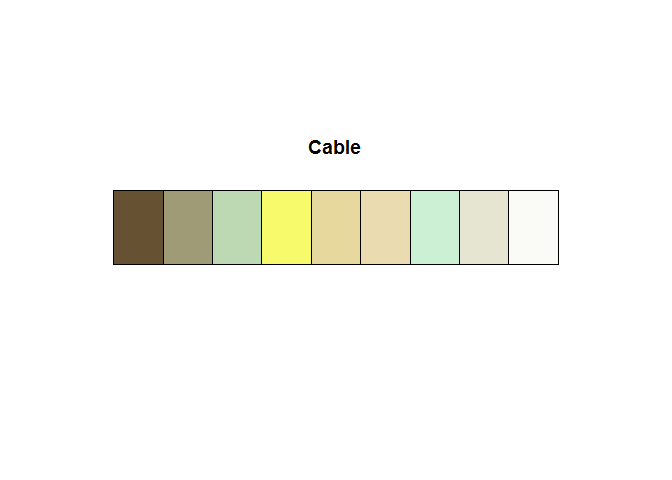

[figure not shown]

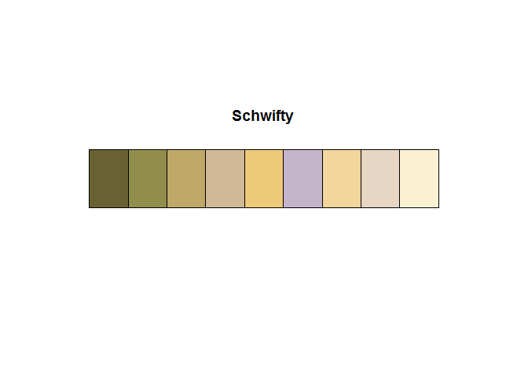

[figure not shown]

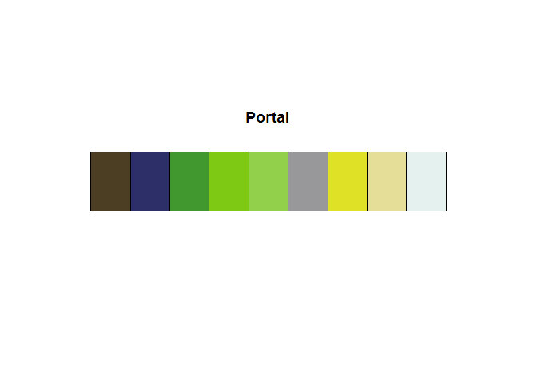

[figure not shown]

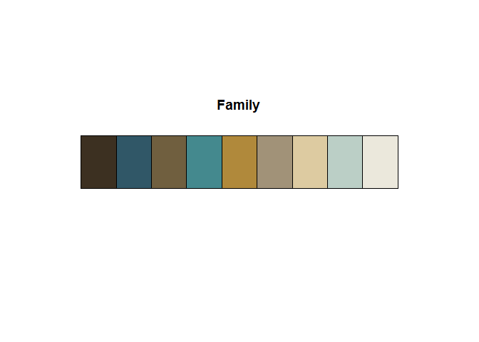

[figure not shown]

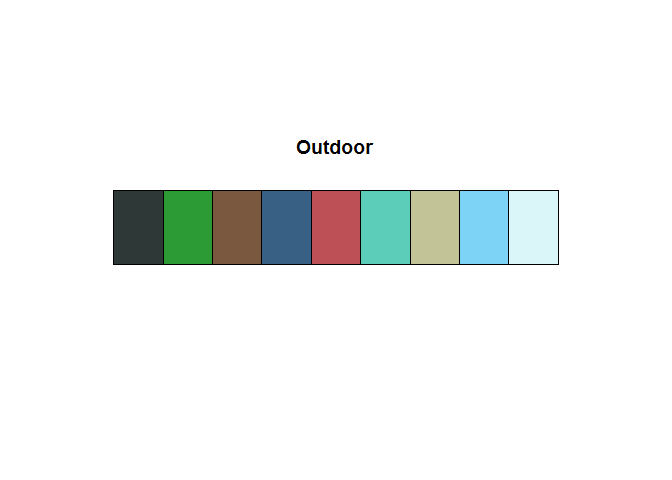

[figure not shown]

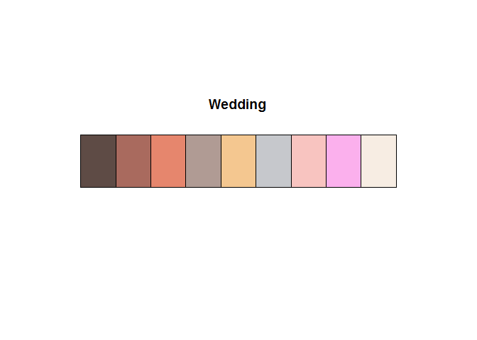

Finally, let’s do what we said we’d do at the beginning, put all these images together and add it to our list column of palettes.

```
multi_img_pal <- gen_pal(rm_list)
palette_rick<-data_frame(name="all",pal=list(multi_img_pal)) %>% bind_rows(palette_rick)
show_col(multi_img_pal)
```

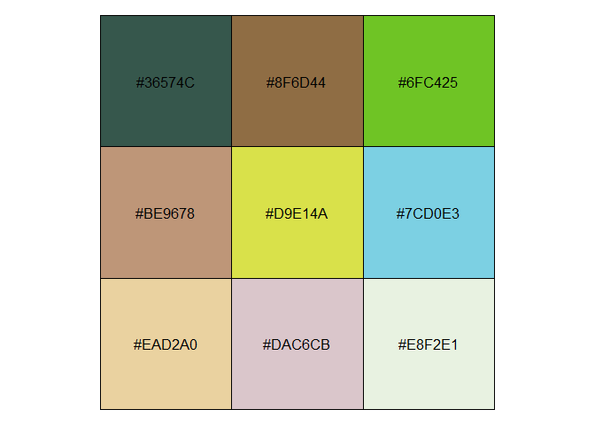

Not too bad. I’m glad something resembling Rick’s hair makes it into the list. Compare it to the ggsci package Rick and Morty palette. Here we see the weaknesses of an algorithmic approach. ggsci is more interesting since it has more color diversity and vividness. I assume they were hand selected. You can see Rick’s hair and Morty’s shirt color.

```
show_col(ggsci::pal_rickandmorty()(9))
```

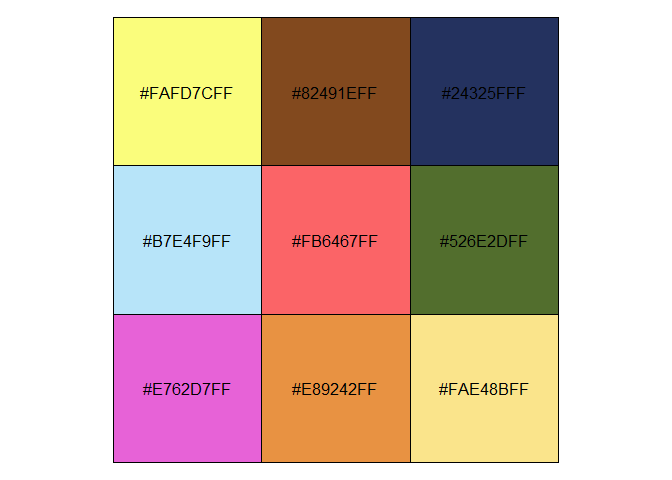

Make some plots.

```
#use the example in help for dplyr::gather
stocks <- data.frame(
  time = as.Date('2009-01-01') + 0:9,
  W = rnorm(10, 0, 1),
  X = rnorm(10, 0, 1),
  Y = rnorm(10, 0, 2),
  Z = rnorm(10, 0, 4)
)
stocksm <- stocks %>% gather(stock, price, -time)

ggplot(stocksm,aes(time,price,color=stock))+geom_line(size=2)+
  scale_color_manual(values = multi_img_pal) + theme_minimal()
```

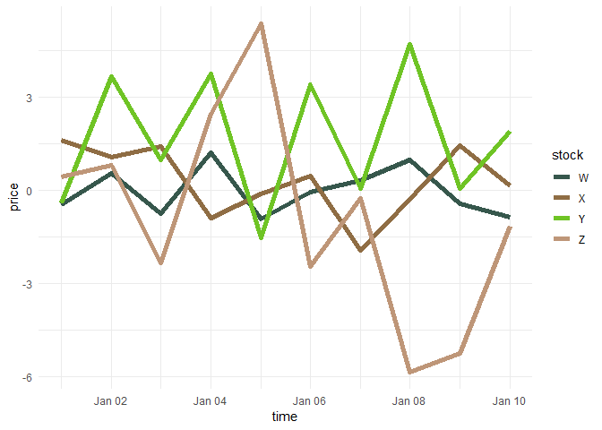

```
ggplot(stocksm,aes(time,price,color=stock))+geom_line(size=2) +
  theme_minimal() +
  scale_color_manual(values = extract_pal(palette_rick,"Wedding"))
```

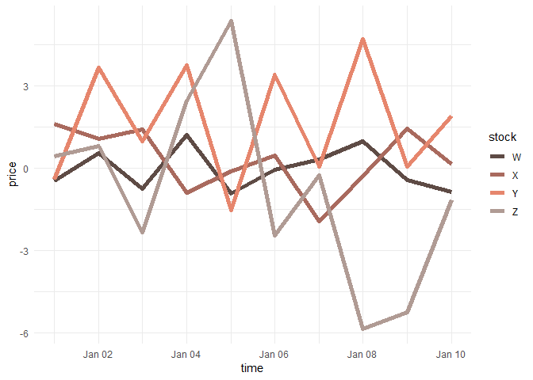